# Marketing Analytics in R

Omer Elmasri

04 07 2019

# MARKETING ANALYTICS IN R : STATISTICAL MODELING

## 1. CUSTOMER LIFETIME VALUE IN CRM

Customer Lifetime Value (CLV) * predicted future net-profit * identify promising customers * prioritize customers according to future margins * no further customer segmentation ** Identification of promising customers ** Minimization of acquisition costs by specific targeting of customers ** Efficient organization of CRM by prioritizing customers ** not for Sending customized ads to special segments of customers

```r
library(readr)
clvData1 <- read_csv("C:/Users/USER/Desktop/capstone-tm/Marketing/Datacamp-datasets/clvData1.csv")
View(clvData1)
```

```r
str(clvData1, give.attr = FALSE)
```

```
## Classes 'spec_tbl_df', 'tbl_df', 'tbl' and 'data.frame': 4191 obs. of  15 variables:
##  $ customerID        : num  2 3 4 5 6 7 8 9 10 11 ...
##  $ nOrders           : num  4 3 12 16 1 2 3 15 16 1 ...
##  $ nItems            : num  7 4 25 29 2 8 4 20 18 2 ...
##  $ daysSinceLastOrder: num  4 272 12 32 47 19 63 23 75 193 ...
##  $ margin            : num  35.8 25.7 63.3 53.7 35.9 ...
##  $ returnRatio       : num  0.25 0.44 0.15 0.03 0 0.18 0 0.01 0.02 1 ...
##  $ shareOwnBrand     : num  0.67 0.33 0.86 0.96 1 0 0.33 0.53 0.27 0 ...
##  $ shareVoucher      : num  0.17 0 0.38 0.17 0 0.86 0.33 0.12 0.6 0 ...
##  $ shareSale         : num  0 0.67 0.29 0.33 1 0.14 0 0.12 0.2 1 ...
##  $ gender            : chr  "female" "male" "male" "female" ...
##  $ age               : num  56 37 32 43 48 31 27 30 50 50 ...
##  $ marginPerOrder    : num  8.94 8.58 5.28 3.36 35.85 ...
##  $ marginPerItem     : num  5.11 6.43 2.53 1.85 17.93 ...
##  $ itemsPerOrder     : num  1.75 1.33 2.08 1.81 2 4 1.33 1.33 1.12 2 ...
##  $ futureMargin      : num  57.6 29.7 56.3 58.8 29.3 ...
```

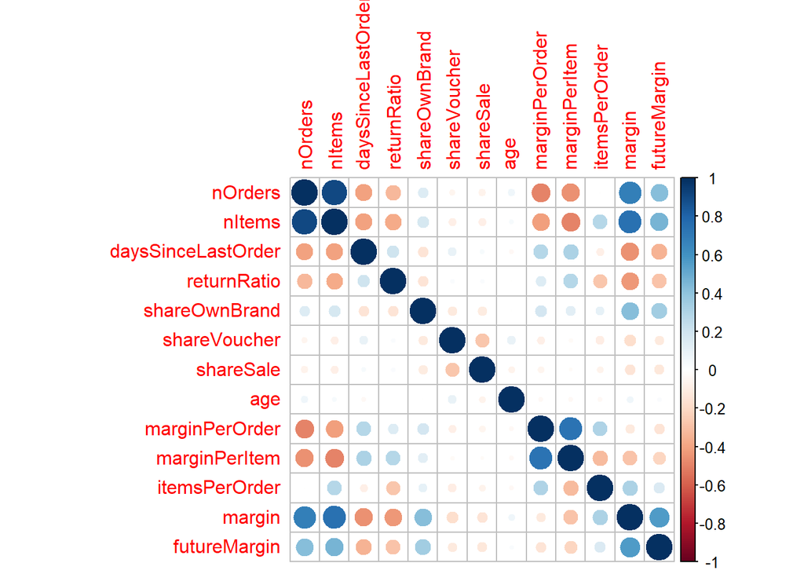

```r
library(corrplot)
library(dplyr)
clvData1 %>%
  select(nOrders, nItems, daysSinceLastOrder, returnRatio, shareOwnBrand, shareVoucher, shareSale, age, marginPerOrder, marginPerItem, itemsPerOrder, margin, futureMargin) %>% cor() %>% corrplot()
```

There are positive correlation between the margin and nOrders and nItems. Contrastly, daysSinceLastOrder and returnRatio moderately have negative correlation with future margin.

## Looking at data

The dataset salesData is loaded in the workspace. It contains information on customers for the months one to three. Only the sales of month four are included. The following table gives a description of some of the variables whose meaning is less obvious.

Variable Description id - identification number of customer mostFreqStore - store person bought mostly from mostFreqCat - category person purchased mostly nCats - number of different categories preferredBrand - brand person purchased mostly nBrands - number of different brands

The packages readr, dplyr, corrplot, and ggplot2 have been installed and loaded.

Now visualize the correlation of the continuous explanatory variables for the past three months with the sales variable of this month.

```r
library(readr)
salesData <- read_csv("C:/Users/USER/Desktop/capstone-tm/Marketing/Datacamp-datasets/salesData.csv")
View(salesData)
```

```r
# Structure of dataset
str(salesData, give.attr = FALSE)
```

```
## Classes 'spec_tbl_df', 'tbl_df', 'tbl' and 'data.frame': 5122 obs. of  14 variables:
##  $ id                   : num  1 2 3 4 5 6 7 8 9 10 ...
##  $ nItems               : num  1469 1463 262 293 108 ...
##  $ mostFreqStore        : chr  "Stockton" "Stockton" "Colorado Springs" "Colorado Springs" ...
##  $ mostFreqCat          : chr  "Alcohol" "Alcohol" "Shoes" "Bakery" ...
##  $ nCats                : num  72 73 55 50 32 41 36 31 41 52 ...
##  $ preferredBrand       : chr  "Veina" "Veina" "Bo" "Veina" ...
##  $ nBrands              : num  517 482 126 108 79 98 78 62 99 103 ...
##  $ nPurch               : num  82 88 56 43 18 35 34 12 26 33 ...
##  $ salesLast3Mon        : num  2742 2791 1530 1766 1180 ...
##  $ salesThisMon         : num  1284 1243 683 730 553 ...
##  $ daysSinceLastPurch   : num  1 1 1 1 12 2 2 4 14 1 ...
##  $ meanItemPrice        : num  1.87 1.91 5.84 6.03 10.93 ...
##  $ meanShoppingCartValue: num  33.4 31.7 27.3 41.1 65.6 ...
##  $ customerDuration     : num  821 657 548 596 603 673 612 517 709 480 ...
```

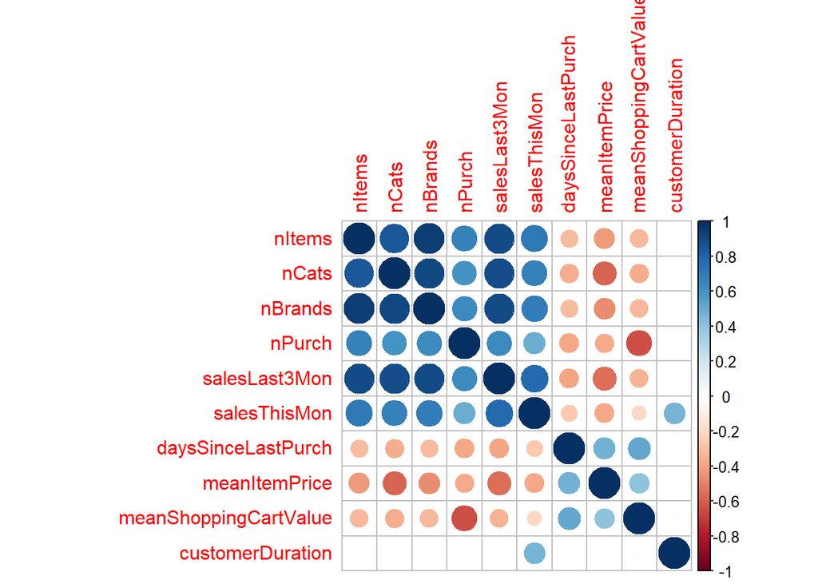

```r
# Visualization of correlations
salesData %>% select_if(is.numeric) %>%
  select(-id) %>%
  cor() %>%
  corrplot()

library(ggplot2)
```

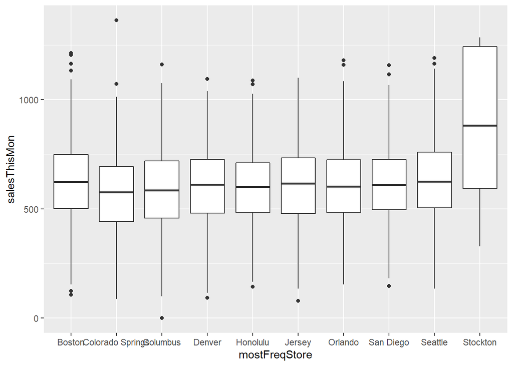

```r
# Frequent stores
ggplot(salesData) +
    geom_boxplot(aes(x = mostFreqStore, y = salesThisMon))
```

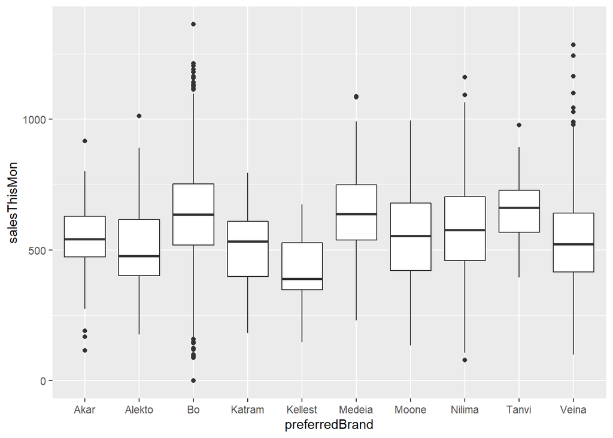

```r
# Preferred brand
ggplot(salesData) +
    geom_boxplot(aes(x = preferredBrand, y = salesThisMon))
```

Which variables are probably well suited to explain the sales of this month? Got an idea? Let’s move on to the simple linear regression.

## SIMPLE LINEAR REGRESSION

```r
simpleLM <- lm(futureMargin ~ margin, data = clvData1)
summary(simpleLM)
```

```
##
## Call:
## lm(formula = futureMargin ~ margin, data = clvData1)
##
## Residuals:
##     Min      1Q  Median      3Q     Max
## -56.055  -9.258   0.727  10.060  49.869
##
## Coefficients:
##             Estimate Std. Error t value Pr(>|t|)
## (Intercept) 12.63068    0.49374   25.58   <2e-16 ***
## margin       0.64543    0.01467   43.98   <2e-16 ***
## ---
## Signif. codes:  0 '***' 0.001 '**' 0.01 '*' 0.05 '.' 0.1 ' ' 1
##
## Residual standard error: 14.24 on 4189 degrees of freedom
## Multiple R-squared:  0.3159, Adjusted R-squared:  0.3158
## F-statistic:  1935 on 1 and 4189 DF,  p-value: < 2.2e-16
```

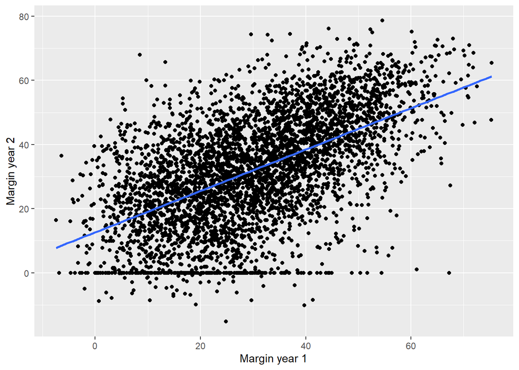

```r
ggplot(clvData1, aes(margin, futureMargin)) +
  geom_point() +
  geom_smooth(method = lm, se = FALSE) +
  xlab("Margin year 1") +
  ylab("Margin year 2")
```

Assumptions of Simple Linear Regression Model * Linear relationship between x and y * No measurement error in x (weak exogeneity) * Independence of errors * Expectation of errors is 0 * Constant variance of prediction errors (homoscedasticity) * Normality of errors

A well-established method to check the violation of these assumptions is a plot of the predicted values against the estimated residuals: RESIDUAL PLOT The residuals are the differences between the predicted and the actual values The residuals are also called prediction errors The residuals in a linear model should be uncorrelated

## Estimating simple linear regression

Back to our sales dataset, salesData, which is already loaded in the workspace. We saw that the sales in the last three months are strongly positively correlated with the sales in this month. Hence we will start off including that as an explanatory variable in a linear regression.

Look at the regression coefficient. Is there a positive or negative relationship between the two variables?

About how much of the variation in the sales in this month can be explained by the sales of the previous three months?

```r
# Model specification using lm
salesSimpleModel <- lm(salesThisMon ~ salesLast3Mon,
                        data = salesData)

# Looking at model summary
summary(salesSimpleModel)
```

```
##
## Call:
## lm(formula = salesThisMon ~ salesLast3Mon, data = salesData)
##
## Residuals:
##     Min      1Q  Median      3Q     Max
## -570.18  -68.26    3.21   72.98  605.58
##
## Coefficients:
##                Estimate Std. Error t value Pr(>|t|)
## (Intercept)   99.690501   6.083886   16.39   <2e-16 ***
## salesLast3Mon  0.382696   0.004429   86.40   <2e-16 ***
## ---
## Signif. codes:  0 '***' 0.001 '**' 0.01 '*' 0.05 '.' 0.1 ' ' 1
##
## Residual standard error: 117.5 on 5120 degrees of freedom
## Multiple R-squared:  0.5932, Adjusted R-squared:  0.5931
## F-statistic:  7465 on 1 and 5120 DF,  p-value: < 2.2e-16
```

Since the regression coefficient is greater than 0, there exists a positive relationship between the explanatory variable salesLast3Mon and the dependent variable salesThisMon. It explains almost 60 percent of the variation in the sales of this month.

## MULTIPLE LINEAR REGRESSION

```r
multipleLM <- lm(futureMargin ~ margin + nOrders + nItems + daysSinceLastOrder +
                    returnRatio + shareOwnBrand + shareVoucher + shareSale +
                    gender + age + marginPerOrder + marginPerItem +
                    itemsPerOrder, data = clvData1)
summary(multipleLM)
```

```
##
## Call:
## lm(formula = futureMargin ~ margin + nOrders + nItems + daysSinceLastOrder +
##     returnRatio + shareOwnBrand + shareVoucher + shareSale +
##     gender + age + marginPerOrder + marginPerItem + itemsPerOrder,
##     data = clvData1)
##
## Residuals:
##     Min      1Q  Median      3Q     Max
## -57.830  -8.926   0.557   9.473  49.822
##
## Coefficients:
##                     Estimate Std. Error t value Pr(>|t|)
## (Intercept)        22.528666   1.435062  15.699  < 2e-16 ***
## margin              0.402783   0.027298  14.755  < 2e-16 ***
## nOrders            -0.031825   0.122980  -0.259  0.79581
## nItems              0.137517   0.070997   1.937  0.05282 .
## daysSinceLastOrder -0.016521   0.002683  -6.157 8.12e-10 ***
## returnRatio        -1.944799   0.601547  -3.233  0.00123 **
## shareOwnBrand       7.654707   0.678893  11.275  < 2e-16 ***
## shareVoucher       -1.830182   0.669253  -2.735  0.00627 **
## shareSale          -2.964308   0.690573  -4.293 1.81e-05 ***
## gendermale          0.179593   0.429459   0.418  0.67583
## age                -0.010303   0.017257  -0.597  0.55051
## marginPerOrder     -0.202354   0.091411  -2.214  0.02691 *
## marginPerItem       0.021231   0.109703   0.194  0.84655
## itemsPerOrder       0.102576   0.540835   0.190  0.84958
## ---
## Signif. codes:  0 '***' 0.001 '**' 0.01 '*' 0.05 '.' 0.1 ' ' 1
##
## Residual standard error: 13.85 on 4177 degrees of freedom
## Multiple R-squared:  0.3547, Adjusted R-squared:  0.3527
## F-statistic: 176.6 on 13 and 4177 DF,  p-value: < 2.2e-16
```

Multicolineraty is one of the treat to a multiple linear regression. Regression coefficents become unstable. Standard errors by the linear model are underestimates. Due to high correlation between nOrders and nItems as well as marginPerOrder and marginPerItem. These are candidates for the multicolineraty.

In order to check multicolineraty systematically, we use Variance Inflation Factor (VIF) from rms package.

```r
library(rms)
vif(multipleLM)
```

```
##             margin            nOrders             nItems
##           3.658257          11.565731          13.141486
## daysSinceLastOrder        returnRatio      shareOwnBrand
##           1.368208           1.311476           1.363515
##       shareVoucher          shareSale         gendermale
##           1.181329           1.148697           1.003452
##                age     marginPerOrder      marginPerItem
##           1.026513           8.977661           7.782651
##      itemsPerOrder
##           6.657435
```

These indicate the increase in the variance of an estimated coefficient due to multicollinearity. A VIF higher than 5 is problematic and values above 10 indicate poor regression estimates. As expected, the vIF’s for nOrders and nItems as well as marginPerOrder and marginPerItem are rather high. Hence we exclude one of each pair from the regression; namely nItems and marginPerOrder.

```r
multipleLM2 <- lm(futureMargin ~ margin + nOrders +
                    daysSinceLastOrder + returnRatio + shareOwnBrand +
                    shareVoucher + shareSale + gender + age +
                    marginPerItem + itemsPerOrder,
                  data = clvData1)

vif(multipleLM2)
```

```
##             margin            nOrders daysSinceLastOrder
##           3.561828           2.868060           1.354986
##        returnRatio      shareOwnBrand       shareVoucher
##           1.305490           1.353513           1.176411
##          shareSale         gendermale                age
##           1.146499           1.003132           1.021518
##      marginPerItem      itemsPerOrder
##           1.686746           1.550524
```

Now all of them are acceptable.

```r
summary(multipleLM2)
```

```
##
## Call:
## lm(formula = futureMargin ~ margin + nOrders + daysSinceLastOrder +
##     returnRatio + shareOwnBrand + shareVoucher + shareSale +
##     gender + age + marginPerItem + itemsPerOrder, data = clvData1)
##
## Residuals:
##     Min      1Q  Median      3Q     Max
## -55.659  -8.827   0.483   9.561  50.118
##
## Coefficients:
##                     Estimate Std. Error t value Pr(>|t|)
## (Intercept)        22.798064   1.287806  17.703  < 2e-16 ***
## margin              0.404200   0.026983  14.980  < 2e-16 ***
## nOrders             0.220255   0.061347   3.590 0.000334 ***
## daysSinceLastOrder -0.017180   0.002675  -6.422 1.49e-10 ***
## returnRatio        -1.992829   0.601214  -3.315 0.000925 ***
## shareOwnBrand       7.568686   0.677572  11.170  < 2e-16 ***
## shareVoucher       -1.750877   0.669017  -2.617 0.008900 **
## shareSale          -2.942525   0.691108  -4.258 2.11e-05 ***
## gendermale          0.203813   0.430136   0.474 0.635643
## age                -0.015158   0.017245  -0.879 0.379462
## marginPerItem      -0.197277   0.051160  -3.856 0.000117 ***
## itemsPerOrder      -0.270260   0.261458  -1.034 0.301354
## ---
## Signif. codes:  0 '***' 0.001 '**' 0.01 '*' 0.05 '.' 0.1 ' ' 1
##
## Residual standard error: 13.87 on 4179 degrees of freedom
## Multiple R-squared:  0.3522, Adjusted R-squared:  0.3504
## F-statistic: 206.5 on 11 and 4179 DF,  p-value: < 2.2e-16
```

Let’s look significant of the coefficients. If the p value last column is smallet than 0,05, we can conclude the coefficient the coefficient is significantly different from 0 at the point 0,05 significance level.

In this example all variables except gender, age and the itemsPerOrder are significant at the 95% confidence level.

Let’s estimate a multiple linear regression! Of course, we want to make use of all variables there are in the dataset.

```r
# Estimating the full model
salesModel1 <- lm(salesThisMon ~ . - id,
                 data = salesData)

# Checking variance inflation factors
vif(salesModel1)
```

```
##                        nItems mostFreqStoreColorado Springs
##                     11.772600                      1.478098
##         mostFreqStoreColumbus           mostFreqStoreDenver
##                      1.746101                      1.289203
##         mostFreqStoreHonolulu           mostFreqStoreJersey
##                      1.338330                      1.317158
##          mostFreqStoreOrlando        mostFreqStoreSan Diego
##                      1.401396                      1.219922
##          mostFreqStoreSeattle         mostFreqStoreStockton
##                      1.794891                      1.070250
##               mostFreqCatBaby             mostFreqCatBakery
##                      1.456921                      1.246035
##          mostFreqCatBeverages            mostFreqCatClothes
##                      1.079007                      1.156841
##         mostFreqCatFresh food        mostFreqCatFrozen food
##                      1.069987                      1.296358
##      mostFreqCatPackaged food               mostFreqCatPets
##                      1.268000                      1.077488
##              mostFreqCatShoes                         nCats
##                      1.417807                      8.402073
##          preferredBrandAlekto              preferredBrandBo
##                      3.844176                     41.075930
##          preferredBrandKatram         preferredBrandKellest
##                      1.632978                      1.713510
##          preferredBrandMedeia           preferredBrandMoone
##                      6.120384                      4.591570
##          preferredBrandNilima           preferredBrandTanvi
##                     22.714376                      1.885777
##           preferredBrandVeina                       nBrands
##                     20.739114                     14.150868
##                        nPurch                 salesLast3Mon
##                      3.083952                      8.697663
##            daysSinceLastPurch                 meanItemPrice
##                      1.585057                      1.987665
##         meanShoppingCartValue              customerDuration
##                      2.247579                      1.004664
```

```r
# Estimating new model by removing information on brand
salesModel2 <- lm(salesThisMon ~ . - id - preferredBrand - nBrands, data = salesData)

# Checking variance inflation factors
vif(salesModel2)
```

```
##                        nItems mostFreqStoreColorado Springs
##                      6.987456                      1.470508
##         mostFreqStoreColumbus           mostFreqStoreDenver
##                      1.737790                      1.283222
##         mostFreqStoreHonolulu           mostFreqStoreJersey
##                      1.335457                      1.299889
##          mostFreqStoreOrlando        mostFreqStoreSan Diego
##                      1.398318                      1.213865
##          mostFreqStoreSeattle         mostFreqStoreStockton
##                      1.788777                      1.052065
##               mostFreqCatBaby             mostFreqCatBakery
##                      1.412755                      1.236939
##          mostFreqCatBeverages            mostFreqCatClothes
##                      1.077907                      1.105054
##         mostFreqCatFresh food        mostFreqCatFrozen food
##                      1.067089                      1.270953
##      mostFreqCatPackaged food               mostFreqCatPets
##                      1.235165                      1.072278
##              mostFreqCatShoes                         nCats
##                      1.384861                      5.813494
##                        nPurch                 salesLast3Mon
##                      3.069046                      8.412520
##            daysSinceLastPurch                 meanItemPrice
##                      1.579426                      1.925494
##         meanShoppingCartValue              customerDuration
##                      2.238410                      1.002981
```

Since none of the variance inflation factors is greater than 10 we can certainly accept the second model. So lets’s move on to the interpretation of the coefficients.

## Model validation, model fit, and prediction

There are several goodness of fit measures used to judge a model’s fit. One is the so-called coefficient od determination, or the Multiple-R-squared. The value of “Multiple R squared” provided the proportion of the dependent variable’s variance that is explained by the regression model, adjusted for the number of variables in the model. F-test is a test for overall fit of the model. It tests whether or not R2 is equal to zero. That is to say, at least one regressor (or a set of regressor) has significant explanatory power. In our model, the p-value of the F-test is smallet than 0.05.Hence the hypothesis of R2 of zero is rejected.

```r
summary(multipleLM2)
```

```
##
## Call:
## lm(formula = futureMargin ~ margin + nOrders + daysSinceLastOrder +
##     returnRatio + shareOwnBrand + shareVoucher + shareSale +
##     gender + age + marginPerItem + itemsPerOrder, data = clvData1)
##
## Residuals:
##     Min      1Q  Median      3Q     Max
## -55.659  -8.827   0.483   9.561  50.118
##
## Coefficients:
##                     Estimate Std. Error t value Pr(>|t|)
## (Intercept)        22.798064   1.287806  17.703  < 2e-16 ***
## margin              0.404200   0.026983  14.980  < 2e-16 ***
## nOrders             0.220255   0.061347   3.590 0.000334 ***
## daysSinceLastOrder -0.017180   0.002675  -6.422 1.49e-10 ***
## returnRatio        -1.992829   0.601214  -3.315 0.000925 ***
## shareOwnBrand       7.568686   0.677572  11.170  < 2e-16 ***
## shareVoucher       -1.750877   0.669017  -2.617 0.008900 **
## shareSale          -2.942525   0.691108  -4.258 2.11e-05 ***
## gendermale          0.203813   0.430136   0.474 0.635643
## age                -0.015158   0.017245  -0.879 0.379462
## marginPerItem      -0.197277   0.051160  -3.856 0.000117 ***
## itemsPerOrder      -0.270260   0.261458  -1.034 0.301354
## ---
## Signif. codes:  0 '***' 0.001 '**' 0.01 '*' 0.05 '.' 0.1 ' ' 1
##
## Residual standard error: 13.87 on 4179 degrees of freedom
## Multiple R-squared:  0.3522, Adjusted R-squared:  0.3504
## F-statistic: 206.5 on 11 and 4179 DF,  p-value: < 2.2e-16
```

Here the model is onlt fit on the same sample data. It may cause overfitting.

There are several ways to avoid overfitting !!!! * AIC () from stats package * stepAIC() from MASS package * out of the sample model validation * cross-validation ……

AIC penalizes every additional explanatory variable, so that we can control for overfitting while developping a model. When comparing two models, the AIC-minimizing model is preferred. Only one AIC value will not draw any conclusion. Automatic model selection can be done using stepAIC() from the MASS package. The other methods will be explained on the next work (Logistic Regression).

```r
AIC(multipleLM2)
```

```
## [1] 33950.45
```

Now we will be using the year-2 data to predict the year-3.

```r
library(readr)
clvData2 <- read_csv("C:/Users/USER/Desktop/capstone-tm/Marketing/Datacamp-datasets/clvData2.csv")
View(clvData2)
```

```r
head(clvData2)
```

```
## # A tibble: 6 x 14
##   customerID nOrders nItems daysSinceLastOr~ margin returnRatio
##        <dbl>   <dbl>  <dbl>            <dbl>  <dbl>       <dbl>
## 1          2      16     40                2   57.6        0.18
## 2          3       1      5              124   29.7        1
## 3          4      15     30               68   56.3        0.16
## 4          5      23     41              103   58.8        0.03
## 5          6       2      4              104   29.3        0
## 6          7       6     10               41   35.7        0.06
## # ... with 8 more variables: shareOwnBrand <dbl>, shareVoucher <dbl>,
## #   shareSale <dbl>, gender <chr>, age <dbl>, marginPerOrder <dbl>,
## #   marginPerItem <dbl>, itemsPerOrder <dbl>
```

```r
predMargin <- predict(multipleLM2,
                      newdata = clvData2)
head(predMargin)
```

```
##        1        2        3        4        5        6
## 51.10204 31.63335 51.90008 52.62200 36.65194 33.84383
```

```r
mean(predMargin, na.rm = TRUE)
```

```
## [1] 33.95147
```

From Learnings from the Model, we learnt: * to predict the future customer lifetime value * to use a linear regression to model a continuous variable * that the variables for modelling and prediction have to carry the same names * that the margin in one year is a good predictor for the margin in the following year * the longer the time since last order, the smaller the expected margin * characteristics like gender and age don’t seem to play a role for the prediction of margin * etc…

## Interpretation of model fit (hands on)

A new dataset called salesData2_4 is loaded in the working space. It contains information on the customers for the months two to four. We want to use this information in order to predict the sales for month 5.

```r
library(readr)
salesData2_4 <- read_csv("C:/Users/USER/Desktop/capstone-tm/Marketing/Datacamp-datasets/salesDataMon2To4.csv")
View(salesData2_4)
```

```r
# getting an overview of new data
summary(salesData2_4)
```

```
##        id           nItems       mostFreqStore      mostFreqCat
##  Min.   :   1   Min.   :   1.0   Length:5173        Length:5173
##  1st Qu.:1372   1st Qu.:  84.0   Class :character   Class :character
##  Median :2733   Median : 155.0   Mode  :character   Mode  :character
##  Mean   :2729   Mean   : 185.9
##  3rd Qu.:4085   3rd Qu.: 257.0
##  Max.   :5455   Max.   :1461.0
##      nCats       preferredBrand        nBrands           nPurch
##  Min.   : 1.00   Length:5173        Min.   :  1.00   Min.   : 1.00
##  1st Qu.:27.00   Class :character   1st Qu.: 45.00   1st Qu.:11.00
##  Median :37.00   Mode  :character   Median : 75.00   Median :17.00
##  Mean   :36.23                      Mean   : 81.66   Mean   :20.02
##  3rd Qu.:46.00                      3rd Qu.:110.00   3rd Qu.:27.00
##  Max.   :74.00                      Max.   :484.00   Max.   :86.00
##  salesLast3Mon  daysSinceLastPurch meanItemPrice     meanShoppingCartValue
##  Min.   : 189   Min.   : 1.000     Min.   :  1.879   Min.   :  17.58
##  1st Qu.:1068   1st Qu.: 2.000     1st Qu.:  6.049   1st Qu.:  53.88
##  Median :1331   Median : 4.000     Median :  8.556   Median :  75.77
##  Mean   :1324   Mean   : 6.589     Mean   : 12.116   Mean   :  91.88
##  3rd Qu.:1570   3rd Qu.: 7.000     3rd Qu.: 12.969   3rd Qu.: 109.74
##  Max.   :2745   Max.   :87.000     Max.   :313.050   Max.   :1147.66
##  customerDuration
##  Min.   :  31.0
##  1st Qu.: 580.0
##  Median : 682.0
##  Mean   : 676.8
##  3rd Qu.: 777.0
##  Max.   :1386.0
```

```r
# predicting sales
predSales5 <- predict(salesModel2, newdata = salesData2_4)

# calculating mean of future sales
mean(predSales5, na.rm = FALSE)
```

```
## [1] 625.1438
```

## Churn Prevention in Online Marketing

The dataset we will be using includes around 45.000 observations of 21 variables. return Customer is our variable of interest.

```r
library(readr)
churnData <- read_csv("C:/Users/USER/Desktop/capstone-tm/Marketing/Datacamp-datasets/churn_data.csv")
View(churnData)
```

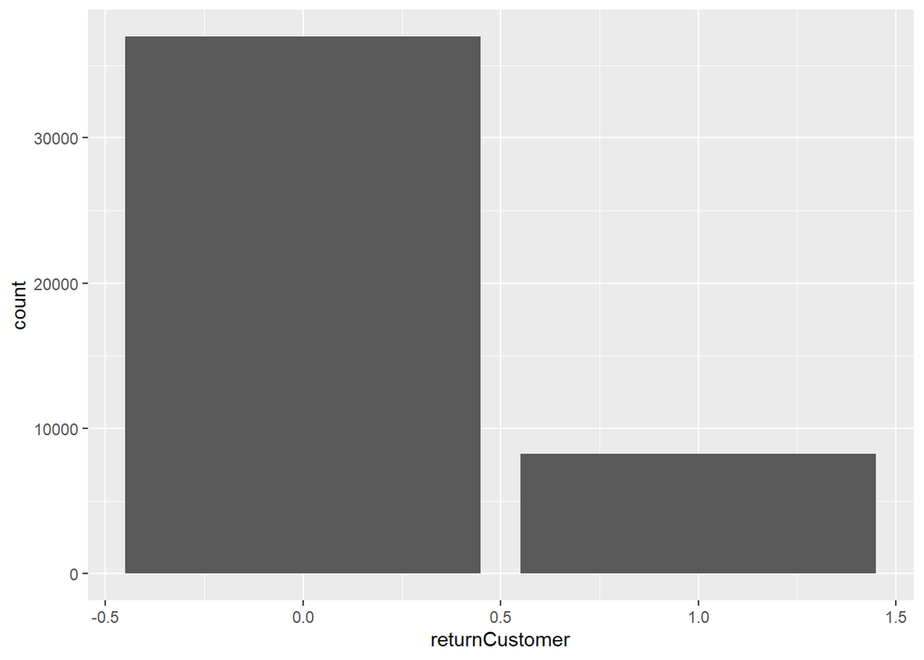

```r
ggplot(churnData, aes(x = returnCustomer)) +
    geom_histogram(stat = "count")
```

```r
# count refers to a bar chart.
```

New dataset is about bank customers and will be used to predict if customers will default on their loan payments.

```r
library(readr)
defaultData <- read_delim("C:/Users/USER/Desktop/capstone-tm/Marketing/Datacamp-datasets/defaultData.csv",
    ";", escape_double = FALSE, trim_ws = TRUE)
View(defaultData)
```

```r
# Summary of data
summary(defaultData)
```

```
##        ID           limitBal            sex          education
##  Min.   :    1   Min.   :  10000   Min.   :1.000   Min.   :0.000
##  1st Qu.: 4501   1st Qu.:  50000   1st Qu.:1.000   1st Qu.:1.000
##  Median : 9000   Median : 130000   Median :2.000   Median :2.000
##  Mean   : 9000   Mean   : 162902   Mean   :1.588   Mean   :1.835
##  3rd Qu.:13500   3rd Qu.: 230000   3rd Qu.:2.000   3rd Qu.:2.000
##  Max.   :18000   Max.   :1000000   Max.   :2.000   Max.   :6.000
##     marriage         age             pay1               pay2
##  Min.   :0.00   Min.   :21.00   Min.   :-2.00000   Min.   :-2.0000
##  1st Qu.:1.00   1st Qu.:28.00   1st Qu.:-1.00000   1st Qu.:-1.0000
##  Median :2.00   Median :34.00   Median : 0.00000   Median : 0.0000
##  Mean   :1.56   Mean   :35.48   Mean   : 0.02783   Mean   :-0.1017
##  3rd Qu.:2.00   3rd Qu.:41.00   3rd Qu.: 0.00000   3rd Qu.: 0.0000
##  Max.   :3.00   Max.   :75.00   Max.   : 8.00000   Max.   : 8.0000
##       pay3              pay4              pay5             pay6
##  Min.   :-2.0000   Min.   :-2.0000   Min.   :-2.000   Min.   :-2.0000
##  1st Qu.:-1.0000   1st Qu.:-1.0000   1st Qu.:-1.000   1st Qu.:-1.0000
##  Median : 0.0000   Median : 0.0000   Median : 0.000   Median : 0.0000
##  Mean   :-0.1294   Mean   :-0.1974   Mean   :-0.228   Mean   :-0.2567
##  3rd Qu.: 0.0000   3rd Qu.: 0.0000   3rd Qu.: 0.000   3rd Qu.: 0.0000
##  Max.   : 8.0000   Max.   : 8.0000   Max.   : 8.000   Max.   : 8.0000
##     billAmt1          billAmt2         billAmt3          billAmt4
##  Min.   :-165580   Min.   :-33350   Min.   : -34041   Min.   :-170000
##  1st Qu.:   3675   1st Qu.:  3149   1st Qu.:   2655   1st Qu.:   2245
##  Median :  22450   Median : 21425   Median :  20035   Median :  18703
##  Mean   :  50030   Mean   : 48131   Mean   :  45607   Mean   :  41074
##  3rd Qu.:  65001   3rd Qu.: 62157   3rd Qu.:  58457   3rd Qu.:  50540
##  Max.   : 964511   Max.   :983931   Max.   :1664089   Max.   : 891586
##     billAmt5         billAmt6          payAmt1          payAmt2
##  Min.   :-37594   Min.   :-339603   Min.   :     0   Min.   :      0
##  1st Qu.:  1684   1st Qu.:   1150   1st Qu.:   949   1st Qu.:    696
##  Median : 18046   Median :  16780   Median :  2087   Median :   2000
##  Mean   : 39398   Mean   :  38009   Mean   :  5532   Mean   :   5731
##  3rd Qu.: 49355   3rd Qu.:  48442   3rd Qu.:  5000   3rd Qu.:   5000
##  Max.   :927171   Max.   : 961664   Max.   :505000   Max.   :1684259
##     payAmt3          payAmt4          payAmt5            payAmt6
##  Min.   :     0   Min.   :     0   Min.   :     0.0   Min.   :     0
##  1st Qu.:   307   1st Qu.:   228   1st Qu.:   209.8   1st Qu.:     2
##  Median :  1500   Median :  1486   Median :  1500.0   Median :  1400
##  Mean   :  4629   Mean   :  4757   Mean   :  4763.7   Mean   :  5135
##  3rd Qu.:  4000   3rd Qu.:  4000   3rd Qu.:  4000.0   3rd Qu.:  4000
##  Max.   :896040   Max.   :497000   Max.   :417990.0   Max.   :528666
##  PaymentDefault
##  Min.   :0.0000
##  1st Qu.:0.0000
##  Median :0.0000
##  Mean   :0.2306
##  3rd Qu.:0.0000
##  Max.   :1.0000
```

```r
# Look at data structure
str(defaultData)
```

```
## Classes 'spec_tbl_df', 'tbl_df', 'tbl' and 'data.frame': 18000 obs. of  25 variables:
##  $ ID            : num  1 2 3 4 5 6 7 8 9 10 ...
##  $ limitBal      : num  20000 120000 90000 50000 50000 50000 500000 100000 140000 20000 ...
##  $ sex           : num  2 2 2 2 1 1 1 2 2 1 ...
##  $ education     : num  2 2 2 2 2 1 1 2 3 3 ...
##  $ marriage      : num  1 2 2 1 1 2 2 2 1 2 ...
##  $ age           : num  24 26 34 37 57 37 29 23 28 35 ...
##  $ pay1          : num  2 -1 0 0 -1 0 0 0 0 -2 ...
##  $ pay2          : num  2 2 0 0 0 0 0 -1 0 -2 ...
##  $ pay3          : num  -1 0 0 0 -1 0 0 -1 2 -2 ...
##  $ pay4          : num  -1 0 0 0 0 0 0 0 0 -2 ...
##  $ pay5          : num  -2 0 0 0 0 0 0 0 0 -1 ...
##  $ pay6          : num  -2 2 0 0 0 0 0 -1 0 -1 ...
##  $ billAmt1      : num  3913 2682 29239 46990 8617 ...
##  $ billAmt2      : num  3102 1725 14027 48233 5670 ...
##  $ billAmt3      : num  689 2682 13559 49291 35835 ...
##  $ billAmt4      : num  0 3272 14331 28314 20940 ...
##  $ billAmt5      : num  0 3455 14948 28959 19146 ...
##  $ billAmt6      : num  0 3261 15549 29547 19131 ...
##  $ payAmt1       : num  0 0 1518 2000 2000 ...
##  $ payAmt2       : num  689 1000 1500 2019 36681 ...
##  $ payAmt3       : num  0 1000 1000 1200 10000 657 38000 0 432 0 ...
##  $ payAmt4       : num  0 1000 1000 1100 9000 ...
##  $ payAmt5       : num  0 0 1000 1069 689 ...
##  $ payAmt6       : num  0 2000 5000 1000 679 ...
##  $ PaymentDefault: num  1 1 0 0 0 0 0 0 0 0 ...
##  - attr(*, "spec")=
##   .. cols(
##   ..   ID = col_double(),
##   ..   limitBal = col_double(),
##   ..   sex = col_double(),
##   ..   education = col_double(),
##   ..   marriage = col_double(),
##   ..   age = col_double(),
##   ..   pay1 = col_double(),
##   ..   pay2 = col_double(),
##   ..   pay3 = col_double(),
##   ..   pay4 = col_double(),
##   ..   pay5 = col_double(),
##   ..   pay6 = col_double(),
##   ..   billAmt1 = col_double(),
##   ..   billAmt2 = col_double(),
##   ..   billAmt3 = col_double(),
##   ..   billAmt4 = col_double(),
##   ..   billAmt5 = col_double(),
##   ..   billAmt6 = col_double(),
##   ..   payAmt1 = col_double(),
##   ..   payAmt2 = col_double(),
##   ..   payAmt3 = col_double(),
##   ..   payAmt4 = col_double(),
##   ..   payAmt5 = col_double(),
##   ..   payAmt6 = col_double(),
##   ..   PaymentDefault = col_double()
##   .. )
```

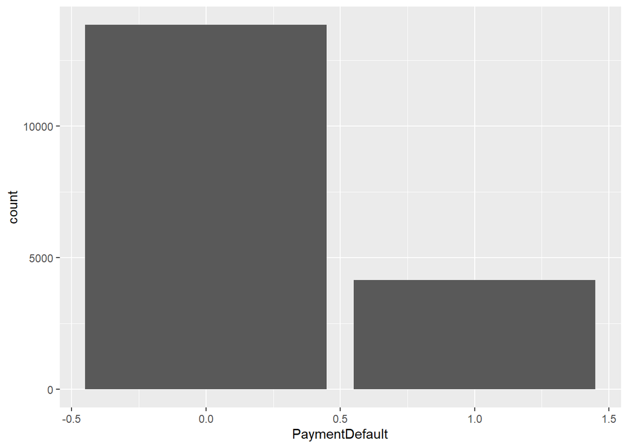

```r
# Analyze the balancedness of dependent variable
ggplot(defaultData,aes(x = PaymentDefault)) +
  geom_histogram(stat = "count")
```

```r
head(churnData)
```

```
## # A tibble: 6 x 22
##      X1    ID orderDate  title newsletter websiteDesign paymentMethod
##   <dbl> <dbl> <date>     <chr>      <dbl>         <dbl> <chr>
## 1     1     1 2014-12-23 Mr             0             2 Current Acco~
## 2     2     3 2014-09-10 Mr             0             1 Invoice
## 3     3     5 2014-08-30 Mr             0             1 Cash
## 4     4     7 2015-01-12 Mr             0             3 Cash
## 5     5     8 2014-09-26 Mr             0             3 Cash
## 6     6     9 2014-07-17 Mr             0             1 Credit Card
## # ... with 15 more variables: couponDiscount <dbl>, purchaseValue <dbl>,
## #   giftwrapping <dbl>, throughAffiliate <dbl>, shippingFees <dbl>,
## #   dvd <dbl>, blueray <dbl>, vinyl <dbl>, videogame <dbl>,
## #   videogameDownload <dbl>, tvEquiment <dbl>, prodOthers <dbl>,
## #   prodRemitted <dbl>, prodSecondHand <dbl>, returnCustomer <dbl>
```

```r
logitModelFull <- glm(returnCustomer ~ title + newsletter + websiteDesign + paymentMethod + couponDiscount + purchaseValue + giftwrapping + throughAffiliate

 + shippingFees + dvd + blueray + vinyl + videogame + videogameDownload + tvEquiment + prodOthers + prodRemitted + prodSecondHand, family = binomial, churnData)

summary(logitModelFull)
```

```
##
## Call:
## glm(formula = returnCustomer ~ title + newsletter + websiteDesign +
##     paymentMethod + couponDiscount + purchaseValue + giftwrapping +
##     throughAffiliate + shippingFees + dvd + blueray + vinyl +
##     videogame + videogameDownload + tvEquiment + prodOthers +
##     prodRemitted + prodSecondHand, family = binomial, data = churnData)
##
## Deviance Residuals:
##     Min       1Q   Median       3Q      Max
## -1.5166  -0.6599  -0.5682  -0.4606   2.3674
##
## Coefficients:
##                              Estimate Std. Error z value Pr(>|z|)
## (Intercept)                  -1.81151    0.07894 -22.949  < 2e-16 ***
## titleMr                       0.21256    0.05286   4.021 5.79e-05 ***
## titleMrs                      0.24188    0.05445   4.442 8.90e-06 ***
## titleOthers                   0.78040    0.05766  13.535  < 2e-16 ***
## newsletter                    0.51996    0.03028  17.169  < 2e-16 ***
## websiteDesign                 0.10515    0.03430   3.066  0.00217 **
## paymentMethodCredit Card     -0.25242    0.04834  -5.221 1.78e-07 ***
## paymentMethodCurrent Account -0.27071    0.04141  -6.537 6.28e-11 ***
## paymentMethodInvoice         -0.24603    0.03608  -6.818 9.21e-12 ***
## couponDiscount               -0.22734    0.04174  -5.447 5.12e-08 ***
## purchaseValue                -0.02693    0.01277  -2.108  0.03505 *
## giftwrapping                  0.01193    0.19016   0.063  0.94998
## throughAffiliate             -0.01585    0.05893  -0.269  0.78791
## shippingFees                 -0.46821    0.04480 -10.451  < 2e-16 ***
## dvd                           0.07159    0.01426   5.020 5.16e-07 ***
## blueray                       0.12250    0.01761   6.954 3.54e-12 ***
## vinyl                         0.05626    0.02276   2.472  0.01344 *
## videogame                    -0.25059    0.11139  -2.250  0.02447 *
## videogameDownload             0.27797    0.05257   5.288 1.24e-07 ***
## tvEquiment                   -0.51552    1.08139  -0.477  0.63356
## prodOthers                   -0.05989    0.07749  -0.773  0.43960
## prodRemitted                  0.89450    0.07617  11.744  < 2e-16 ***
## prodSecondHand                0.16179    0.09934   1.629  0.10339
## ---
## Signif. codes:  0 '***' 0.001 '**' 0.01 '*' 0.05 '.' 0.1 ' ' 1
##
## (Dispersion parameter for binomial family taken to be 1)
##
##     Null deviance: 43038  on 45235  degrees of freedom
## Residual deviance: 41727  on 45213  degrees of freedom
## AIC: 41773
##
## Number of Fisher Scoring iterations: 4
```

```r
# Coefficient Interpretation
coefsExp <- coef(logitModelFull) %>% exp() %>% round(2)
coefsExp
```

```
##                  (Intercept)                      titleMr
##                         0.16                         1.24
##                     titleMrs                  titleOthers
##                         1.27                         2.18
##                   newsletter                websiteDesign
##                         1.68                         1.11
##     paymentMethodCredit Card paymentMethodCurrent Account
##                         0.78                         0.76
##         paymentMethodInvoice               couponDiscount
##                         0.78                         0.80
##                purchaseValue                 giftwrapping
##                         0.97                         1.01
##             throughAffiliate                 shippingFees
##                         0.98                         0.63
##                          dvd                      blueray
##                         1.07                         1.13
##                        vinyl                    videogame
##                         1.06                         0.78
##            videogameDownload                   tvEquiment
##                         1.32                         0.60
##                   prodOthers                 prodRemitted
##                         0.94                         2.45
##               prodSecondHand
##                         1.18
```

```r
# Model Selection
library(MASS)
logitModelNew <- stepAIC(logitModelFull, trace = 0)

summary(logitModelNew)
```

```
##
## Call:
## glm(formula = returnCustomer ~ title + newsletter + websiteDesign +
##     paymentMethod + couponDiscount + purchaseValue + shippingFees +
##     dvd + blueray + vinyl + videogame + videogameDownload + prodRemitted +
##     prodSecondHand, family = binomial, data = churnData)
##
## Deviance Residuals:
##     Min       1Q   Median       3Q      Max
## -1.5147  -0.6603  -0.5679  -0.4606   2.3692
##
## Coefficients:
##                              Estimate Std. Error z value Pr(>|z|)
## (Intercept)                  -1.80497    0.07512 -24.027  < 2e-16 ***
## titleMr                       0.21140    0.05283   4.001 6.30e-05 ***
## titleMrs                      0.24169    0.05445   4.439 9.04e-06 ***
## titleOthers                   0.77973    0.05765  13.526  < 2e-16 ***
## newsletter                    0.51938    0.03027  17.157  < 2e-16 ***
## websiteDesign                 0.09725    0.01624   5.989 2.11e-09 ***
## paymentMethodCredit Card     -0.25426    0.04820  -5.275 1.33e-07 ***
## paymentMethodCurrent Account -0.26979    0.04136  -6.524 6.87e-11 ***
## paymentMethodInvoice         -0.24497    0.03602  -6.801 1.04e-11 ***
## couponDiscount               -0.23073    0.04058  -5.686 1.30e-08 ***
## purchaseValue                -0.02761    0.01271  -2.173   0.0298 *
## shippingFees                 -0.46860    0.04478 -10.465  < 2e-16 ***
## dvd                           0.07241    0.01419   5.102 3.36e-07 ***
## blueray                       0.12283    0.01756   6.997 2.62e-12 ***
## vinyl                         0.05722    0.02270   2.521   0.0117 *
## videogame                    -0.24845    0.11136  -2.231   0.0257 *
## videogameDownload             0.28187    0.05200   5.421 5.94e-08 ***
## prodRemitted                  0.89434    0.07617  11.742  < 2e-16 ***
## prodSecondHand                0.16387    0.09924   1.651   0.0987 .
## ---
## Signif. codes:  0 '***' 0.001 '**' 0.01 '*' 0.05 '.' 0.1 ' ' 1
##
## (Dispersion parameter for binomial family taken to be 1)
##
##     Null deviance: 43038  on 45235  degrees of freedom
## Residual deviance: 41728  on 45217  degrees of freedom
## AIC: 41766
##
## Number of Fisher Scoring iterations: 4
```

Here important function stepAIC is iteratively compared to several other models such that variables are dropped and added based on their significance. The process goes on on as long as the AIC value decreases and stops when a minimum is reached.

Here there is hidden the intermediate steps with trace=0.

At the end of this process, we will see a model with fewer explanatory variables and a superior AIC value. Values that were dropped are mostly unspesific variables like tvEquipmetn. Now we focus on this model however normally we should check other models, too.

# Model specification and estimation

You have seen the glm() command for running a logistic regression. glm() stands for generalized linear model and offers a whole family of regression models.

Take the exercise dataset for this coding task. The data defaultData you need for this exercise is available in your environment and ready for modeling.

Use the glm() function in order to model the probability that a customer will default on his payment by using a logistic regression. Include every explanatory variable of the dataset and specify the data that shall be used. Do not forget to specify the argument family. Then, extract the coefficients and transform them to the odds ratios.

```r
# Build logistic regression model
logitModelFull <- glm(PaymentDefault ~ limitBal + sex + education + marriage +
                   age + pay1 + pay2 + pay3 + pay4 + pay5 + pay6 + billAmt1 +
                   billAmt2 + billAmt3 + billAmt4 + billAmt5 + billAmt6 + payAmt1 +
                   payAmt2 + payAmt3 + payAmt4 + payAmt5 + payAmt6,
                 family = binomial, data = defaultData)

# Take a look at the model
summary(logitModelFull)
```

```
##
## Call:
## glm(formula = PaymentDefault ~ limitBal + sex + education + marriage +
##     age + pay1 + pay2 + pay3 + pay4 + pay5 + pay6 + billAmt1 +
##     billAmt2 + billAmt3 + billAmt4 + billAmt5 + billAmt6 + payAmt1 +
##     payAmt2 + payAmt3 + payAmt4 + payAmt5 + payAmt6, family = binomial,
##     data = defaultData)
##
## Deviance Residuals:
##     Min       1Q   Median       3Q      Max
## -3.0893  -0.7116  -0.5615  -0.2794   4.2501
##
## Coefficients:
##               Estimate Std. Error z value Pr(>|z|)
## (Intercept) -5.711e-01  1.505e-01  -3.795 0.000148 ***
## limitBal    -4.825e-07  1.985e-07  -2.431 0.015052 *
## sex         -8.251e-02  3.880e-02  -2.127 0.033457 *
## education   -1.217e-01  2.745e-02  -4.434 9.23e-06 ***
## marriage    -1.711e-01  4.016e-02  -4.259 2.05e-05 ***
## age          4.824e-03  2.257e-03   2.137 0.032570 *
## pay1         5.743e-01  2.221e-02  25.864  < 2e-16 ***
## pay2         5.156e-02  2.552e-02   2.020 0.043336 *
## pay3         7.811e-02  2.863e-02   2.728 0.006375 **
## pay4        -1.191e-02  3.285e-02  -0.363 0.716838
## pay5         1.080e-01  3.381e-02   3.193 0.001406 **
## pay6        -1.956e-02  2.750e-02  -0.711 0.476852
## billAmt1    -7.948e-06  1.582e-06  -5.023 5.09e-07 ***
## billAmt2     4.911e-06  2.006e-06   2.448 0.014350 *
## billAmt3     4.203e-07  1.698e-06   0.247 0.804572
## billAmt4    -1.587e-08  1.872e-06  -0.008 0.993234
## billAmt5     9.703e-07  2.154e-06   0.451 0.652293
## billAmt6     6.758e-07  1.591e-06   0.425 0.670955
## payAmt1     -1.878e-05  3.252e-06  -5.777 7.61e-09 ***
## payAmt2     -6.406e-06  2.364e-06  -2.710 0.006731 **
## payAmt3     -3.325e-06  2.401e-06  -1.385 0.166153
## payAmt4     -3.922e-06  2.342e-06  -1.675 0.093970 .
## payAmt5     -2.383e-06  2.168e-06  -1.099 0.271635
## payAmt6     -1.916e-06  1.618e-06  -1.184 0.236521
## ---
## Signif. codes:  0 '***' 0.001 '**' 0.01 '*' 0.05 '.' 0.1 ' ' 1
##
## (Dispersion parameter for binomial family taken to be 1)
##
##     Null deviance: 19438  on 17999  degrees of freedom
## Residual deviance: 17216  on 17976  degrees of freedom
## AIC: 17264
##
## Number of Fisher Scoring iterations: 5
```

```r
# Take a look at the odds
coefsexp <- coef(logitModelFull) %>% exp() %>% round(2)
coefsexp
```

```
## (Intercept)    limitBal         sex   education    marriage         age
##        0.56        1.00        0.92        0.89        0.84        1.00
##        pay1        pay2        pay3        pay4        pay5        pay6
##        1.78        1.05        1.08        0.99        1.11        0.98
##    billAmt1    billAmt2    billAmt3    billAmt4    billAmt5    billAmt6
##        1.00        1.00        1.00        1.00        1.00        1.00
##     payAmt1     payAmt2     payAmt3     payAmt4     payAmt5     payAmt6
##        1.00        1.00        1.00        1.00        1.00        1.00
```

# Model specification

The stepAIC() function gives back a reduced model, as you just saw in the previous video. Now you want to apply this method to the exercise dataset defaultData.

The prepared dataset is available in your environment. Additionally, the MASS package is loaded and the previously built logit model logitModelFull is defined for you. Also note that we’ve reduced the size of the dataset as performing stepwise model selection can take a long time with larger datasets and more complex models.

Make use of the stepAIC() function. Set trace = 0, as you do not want to get an output for the whole model selection process. Save the result to the object logitModelNew. Then, use the summary() function to take a look at logitModelNew. You can ignore the warning message in this case. Go ahead and see what changed. Understand the results. The formula is saved in an object so that you don’t have to type the whole equation again when you want to use it later.

```r
library(MASS)
# The old (full) model
logitModelFull <- glm(PaymentDefault ~ limitBal + sex + education + marriage +
                   age + pay1 + pay2 + pay3 + pay4 + pay5 + pay6 + billAmt1 +
                   billAmt2 + billAmt3 + billAmt4 + billAmt5 + billAmt6 + payAmt1 +
                   payAmt2 + payAmt3 + payAmt4 + payAmt5 + payAmt6,
                 family = binomial, defaultData)

#Build the new model
logitModelNew <- stepAIC(logitModelFull, trace = 0)

#Look at the model
summary(logitModelNew)
```

```
##
## Call:
## glm(formula = PaymentDefault ~ limitBal + sex + education + marriage +
##     age + pay1 + pay2 + pay3 + pay5 + billAmt1 + billAmt2 + billAmt5 +
##     payAmt1 + payAmt2 + payAmt3 + payAmt4, family = binomial,
##     data = defaultData)
##
## Deviance Residuals:
##     Min       1Q   Median       3Q      Max
## -3.0839  -0.7119  -0.5611  -0.2839   4.1800
##
## Coefficients:
##               Estimate Std. Error z value Pr(>|z|)
## (Intercept) -5.699e-01  1.504e-01  -3.790 0.000151 ***
## limitBal    -5.201e-07  1.954e-07  -2.661 0.007791 **
## sex         -8.206e-02  3.878e-02  -2.116 0.034338 *
## education   -1.212e-01  2.744e-02  -4.418 9.96e-06 ***
## marriage    -1.724e-01  4.014e-02  -4.295 1.75e-05 ***
## age          4.863e-03  2.256e-03   2.156 0.031092 *
## pay1         5.740e-01  2.218e-02  25.882  < 2e-16 ***
## pay2         4.979e-02  2.552e-02   1.951 0.051048 .
## pay3         7.197e-02  2.573e-02   2.798 0.005146 **
## pay5         8.859e-02  2.249e-02   3.938 8.20e-05 ***
## billAmt1    -8.130e-06  1.580e-06  -5.144 2.69e-07 ***
## billAmt2     5.238e-06  1.775e-06   2.951 0.003165 **
## billAmt5     1.790e-06  8.782e-07   2.038 0.041554 *
## payAmt1     -1.931e-05  3.258e-06  -5.928 3.06e-09 ***
## payAmt2     -6.572e-06  2.092e-06  -3.142 0.001681 **
## payAmt3     -3.693e-06  2.187e-06  -1.689 0.091241 .
## payAmt4     -4.611e-06  2.062e-06  -2.237 0.025306 *
## ---
## Signif. codes:  0 '***' 0.001 '**' 0.01 '*' 0.05 '.' 0.1 ' ' 1
##
## (Dispersion parameter for binomial family taken to be 1)
##
##     Null deviance: 19438  on 17999  degrees of freedom
## Residual deviance: 17220  on 17983  degrees of freedom
## AIC: 17254
##
## Number of Fisher Scoring iterations: 5
```

```r
# Save the formula of the new model (it will be needed for the out-of-sample part)
formulaLogit <- as.formula(summary(logitModelNew)$call)
formulaLogit
```

```
## PaymentDefault ~ limitBal + sex + education + marriage + age +
##     pay1 + pay2 + pay3 + pay5 + billAmt1 + billAmt2 + billAmt5 +
##     payAmt1 + payAmt2 + payAmt3 + payAmt4
```

# In-sample Model Fit and Thresholding

We will evaluate the model. There are some pseudo R2 statistics such as McFadden, Cox&Snell, Nagelkerke. For these statistics, values greater than 0.2. We classify a model as reasonable, greater than 0.4 as good. Greater than 0.5 is very good.

Shortly, Reasonable if >0.2 good >0.4 Very good >0.5

The logRegR2() function from descr package gives us several goodnes of fit measures all of which tells us that the explanatory powe is poor.

```r
library(descr)
LogRegR2(logitModelNew)
```

```
## Chi2                 2217.94
## Df                   16
## Sig.                 0
## Cox and Snell Index  0.1159299
## Nagelkerke Index     0.1755533
## McFadden's R2        0.1141028
```

The algorithm seems to have trouble in explaining a big portion of the variance. Do not forget the phrase: “Garbage in garbage out” It means that a model can only be as good as the data you have.

# Predict Probabilities

Another goodnes of fit measures is called accuracy.

```r
library(SDMTools)
# churnData$predNew <- predict(logitModelNew, type = "response", na.action = na.exclude)
# data %>% select(returnCustomer, predNew) %>% tail()
```

# Confusion Matrix

```r
# confMatrixNew <- confusion.matrix(churnData$returnCustomer, churnData$predNew, threshold = 0.5)
# confMatrixNew
```

# Accuracy

```r
# accuracyNew <- sum(diag(confMatrixNew)) / sum(confMatrixNew)
# accuracyNew
```

# Finding the Optimal Threshold

Do not trust only high accuracies. The misclassifcation ones cost higher. We need the optimal threshold. Like: payoff= 5*truenegative - 15*falsenegative The payoff is dependent on the true-positives and false-negatives. #### cHECK DATACAMP VIDES AGAIN FOR DETAILS.

BE CAREFULL WİTH OVERFITTING ISSUE.

# In-sample fit full model

It is coding time again, which means coming back to the exercise dataset defaultData.

You now want to know how your model performs by calculating the accuracy. In order to do so, you first need a confusion matrix.

Take the logitModelFull, first. The model is already specified and lives in your environment.

Use predict() to receive a probability of each customer defaulting on their payment. In order to construct the confusion matrix use the function confusion.matrix() from SDMTools. Choose a common threshold of 0.5. Calculate the accuracy using the confusion matrix.

```r
# Make predictions using the full Model
defaultData$predFull <- predict(logitModelFull, type = "response", na.action = na.exclude)

# Construct the in-sample confusion matrix
confMatrixModelFull <- confusion.matrix(defaultData$PaymentDefault, defaultData$predFull, threshold = 0.5)
confMatrixModelFull
```

```
##     obs
## pred     0    1
##    0 13441 3154
##    1   409  996
## attr(,"class")
## [1] "confusion.matrix"
```

```r
# Calculate the accuracy for the full Model
accuracyFull <- sum(diag(confMatrixModelFull)) / sum(confMatrixModelFull)
accuracyFull
```

```
## [1] 0.8020556
```

# In-sample fit restricted model

You calculated the accuracy for logitModelFull. It’s very important to do that with all your model candidates.

Therefore,logitModelNew is specified and lives in your environment.

When comparing the values of the different models with each other: In case different models have the same accuracy values, always choose the model with less explanatory variables.

Do the same steps as in the previous exercise for the new model. Use predict() to receive a probability for each customer to default his payment. Then calculate a confusion matrix with the same threshold of 0.5 for classification. Calculate the accuracy of the restricted model and compare it to the accuracy od the full model. You will continue your analysis only with the superior model.

```r
# Calculate the accuracy for 'logitModelNew'
# Make prediction
defaultData$predNew <- predict(logitModelNew, type = "response", na.action = na.exclude)

# Construct the in-sample confusion matrix
confMatrixModelNew <- confusion.matrix(defaultData$PaymentDefault, defaultData$predNew, threshold = 0.5)
confMatrixModelNew
```

```
##     obs
## pred     0    1
##    0 13443 3152
##    1   407  998
## attr(,"class")
## [1] "confusion.matrix"
```

```r
# Calculate the accuracy...
accuracyNew <- sum(diag(confMatrixModelNew)) / sum(confMatrixModelNew)
accuracyNew
```

```
## [1] 0.8022778
```

```r
# and compare it to the full model's accuracy
accuracyFull
```

```
## [1] 0.8020556
```

We calculated the accuracy measures for both model candidates. As the accuracy values are approximately the same, let’s continue with the smaller model logitModelNew.

# Finding the optimal threshold

Imagine you are running a campaign with the aim of preventing customers to default. You can lay out your campaign with the help of your predictions. Thereby, the choice of the threshold is essential for your results. If you know the costs and the rewards of your campaign, you can empirically check which threshold is most reasonable.

We specified the dataframe payoffMatrix for you that contains the column threshold with the thresholds 0.1,0.2,…,0.5. Additionally, it contains an empty column payoff. From the last exercise we know that the restricted model was the best one. So only calculate the optimal threshold for that model. The predictions are stored in the column predNew of the defaultData dataframe.

Don’t be scared of all that code. Just move along line by line.

Build a for loop over the elements of the threshold sequence, which constructs a confusion matrix for each respective threshold value. Use the SDMTools package. In the next step inside the loop calculate the payoff according to the following instructions and store it in the payoff column of the payoffMatrix. The payoff is calculated according to the specific costs given in the following scenario: If a customer does not default due to our campaign, i.e. if we predicted the default truly we are rewarded with 1000€. If however we aim our campaign at a customer who would not have defaulted anyways, i.e. if we falsely predicted the customer to default, we are faced with costs of 250€. This leads to the formula below:

payoff = 1000€ * true positives - 250€ * false positives

Remember the threshold that leads to the highest payoff.

```r
library(SDMTools)
# Prepare data frame with threshold values and empty payoff column
payoffMatrix <- data.frame(threshold = seq(from = 0.1, to = 0.5, by = 0.1),
                           payoff = NA)
payoffMatrix
```

```
##   threshold payoff
## 1       0.1     NA
## 2       0.2     NA
## 3       0.3     NA
## 4       0.4     NA
## 5       0.5     NA
```

```r
for(i in 1:length(payoffMatrix$threshold)) {
  # Calculate confusion matrix with varying threshold
  confMatrix <- confusion.matrix(defaultData$PaymentDefault,
                defaultData$predNew,
                threshold = payoffMatrix$threshold[i])
  # Calculate payoff and save it to the corresponding row
  payoffMatrix$payoff[i] <- confMatrix[2,2]*1000 + confMatrix[2,1]*(-250)
}
payoffMatrix
```

```
##   threshold  payoff
## 1       0.1  994250
## 2       0.2 1440250
## 3       0.3 1575500
## 4       0.4 1328750
## 5       0.5  896250
```

We could see that the optimal threshold is 0.3.

# Out-of-sample validation and cross validation

```r
# Generating random index for training and test set
# set.seed ensures reproducibility of random components
set.seed(534381)

churnData$isTrain <- rbinom(nrow(churnData), 1, 0.66)
train <- subset(churnData, churnData$isTrain == 1)
test <- subset(churnData, churnData$isTrain == 0)
```

```r
# Modeling logitTrainNew
logitTrainNew <- glm( returnCustomer ~ title + newsletter + websiteDesign +
        paymentMethod + couponDiscount + purchaseValue + throughAffiliate +
        shippingFees + dvd + blueray + vinyl + videogameDownload +
        prodOthers + prodRemitted, family = binomial, data = train)

# Out-of-sample prediction for logitTrainNew
test$predNew <- predict(logitTrainNew, type = "response", newdata = test)
```

# Out-of-Sample Accuracy

```r
#calculating the confusion matrix
confMatrixNew <- confusion.matrix(test$returnCustomer, test$predNew,
                 threshold = 0.3)
confMatrixNew
```

```
##     obs
## pred     0    1
##    0 11934 2451
##    1   721  348
## attr(,"class")
## [1] "confusion.matrix"
```

```r
#calculating the accuracy
accuracyNew <- sum(diag(confMatrixNew)) / sum(confMatrixNew)
accuracyNew
```

```
## [1] 0.7947457
```

# Cross-Validation: Set-up

Cross-validation is an even better tool for preventing overfitting since it needs less data than out-of-sample validation.

# Cross-Validation: Accuracy

# Accuracy

glm function from the boot package allows us to implement cross-validation for linear models.

The model evaulation does not stop here. Then we can improve it as changing variables as adding and removing them.

# Assessing out-of-sample model fit